# 预测：方法与实践 2 时间序列图形

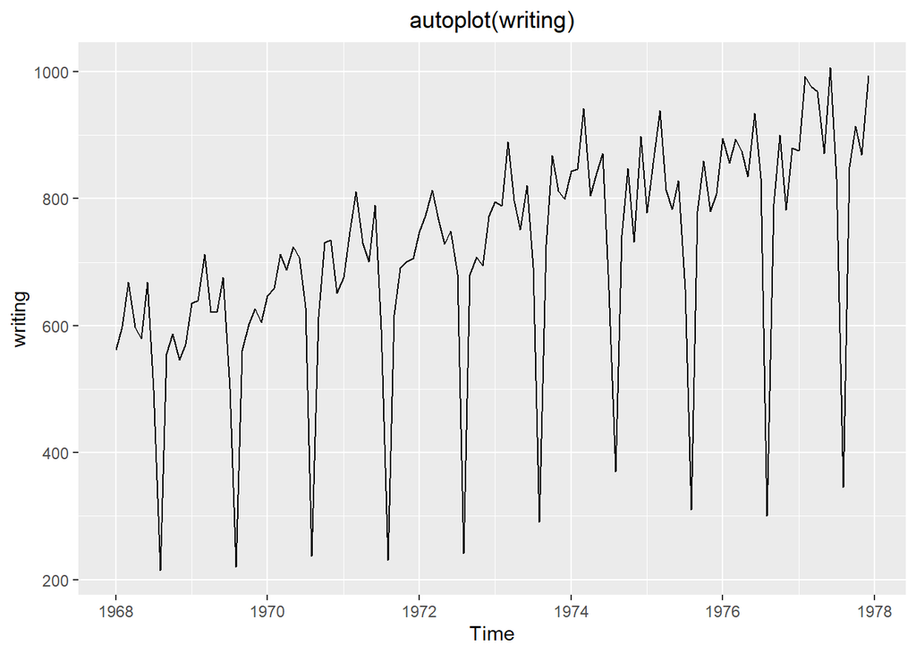

```r
autoplot(writing) +
  ggtitle("autoplot(writing)") +
  theme(text = element_text()) +
  theme(plot.title = element_text(hjust = 0.5))
```

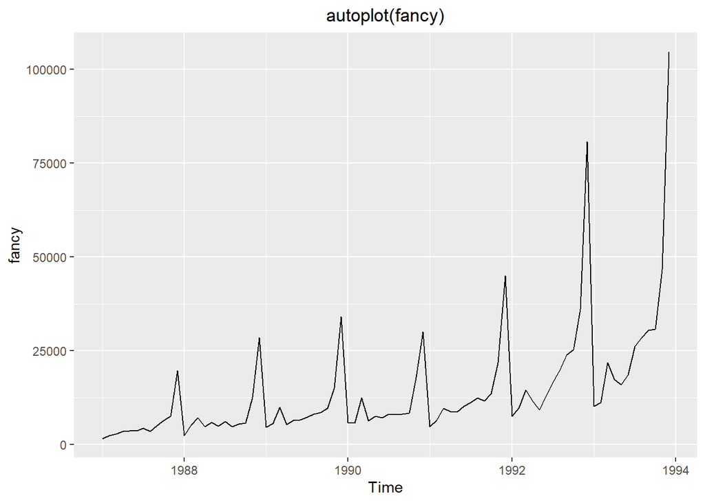

```r
autoplot(fancy) +
  ggtitle("autoplot(fancy)") +
  theme(text = element_text()) +
  theme(plot.title = element_text(hjust = 0.5))
```

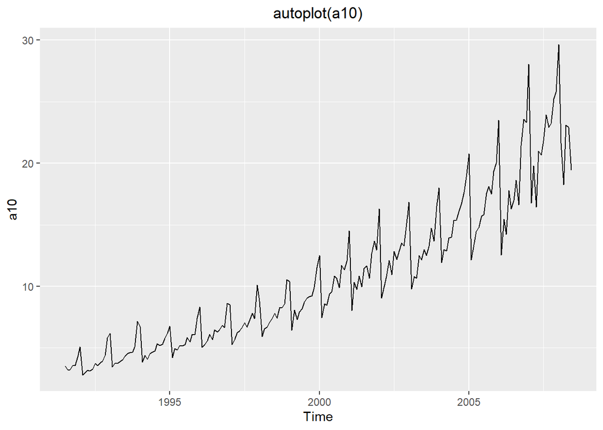

```r
autoplot(a10) +
  ggtitle("autoplot(a10)") +
  theme(text = element_text()) +
  theme(plot.title = element_text(hjust = 0.5))
```

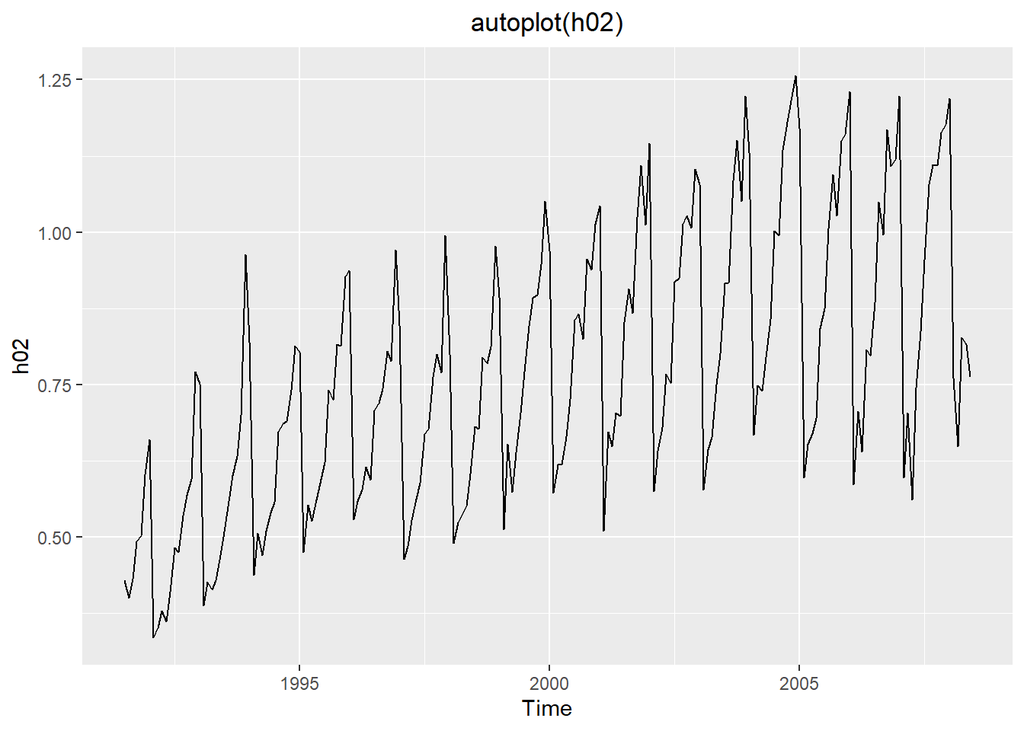

```r
autoplot(h02) +
  ggtitle("autoplot(h02)") +
  theme(text = element_text()) +
  theme(plot.title = element_text(hjust = 0.5))
```

5. 使用`ggseasonplot()`函数和`ggsubseriesplot()`函数来观察`writing`、`fancy`、`a10`和`h02`四个序列的季节性特征。

- 你对时间序列的季节性有什么认识？
- 你可以识别出异常的年份吗？

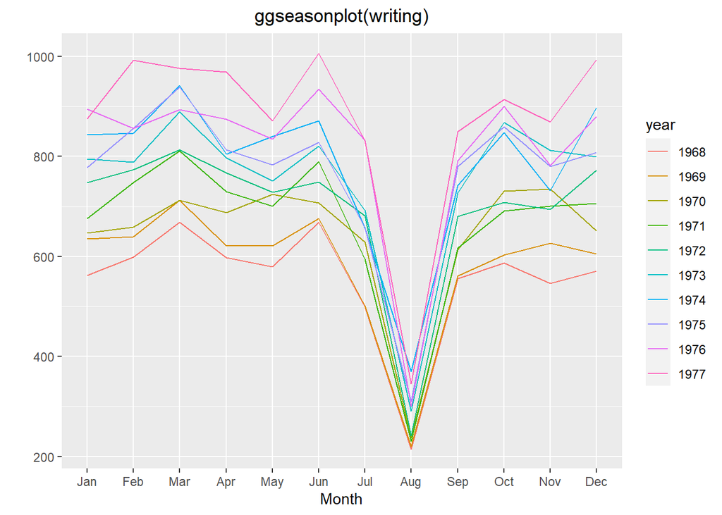

```r
ggseasonplot(writing) +
  ggtitle("ggseasonplot(writing)") +
  theme(text = element_text()) +
  theme(plot.title = element_text(hjust = 0.5))
```

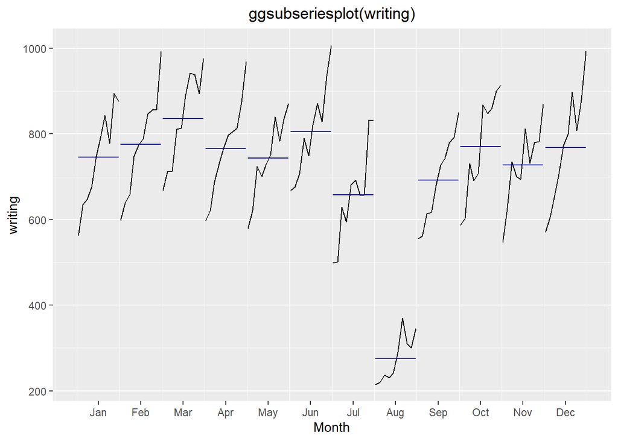

```r
ggsubseriesplot(writing) +
  ggtitle("ggsubseriesplot(writing)") +
  theme(text = element_text()) +
  theme(plot.title = element_text(hjust = 0.5))
```

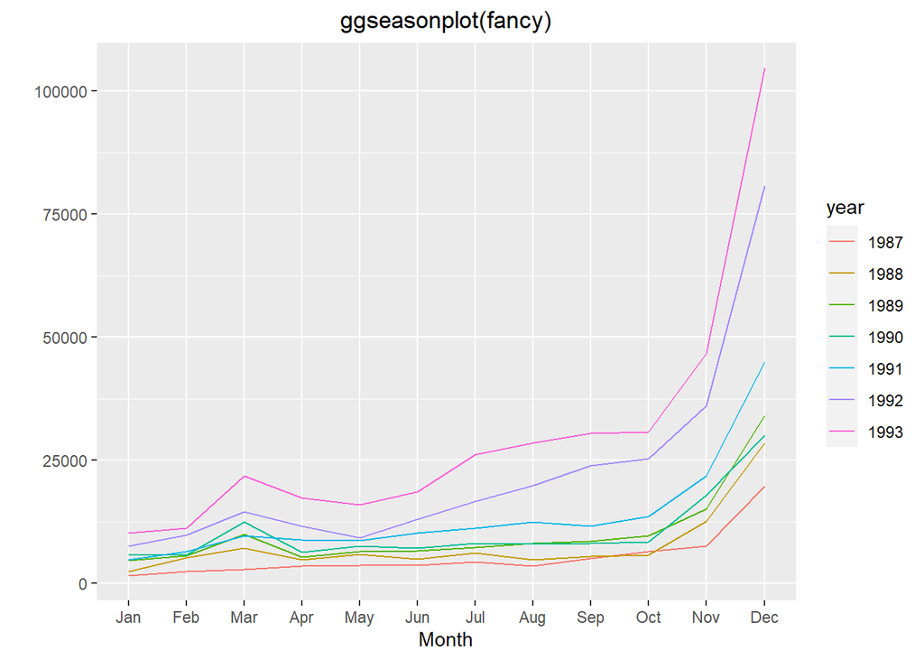

```r
ggseasonplot(fancy) +
  ggtitle("ggseasonplot(fancy)") +
  theme(text = element_text()) +
  theme(plot.title = element_text(hjust = 0.5))
```

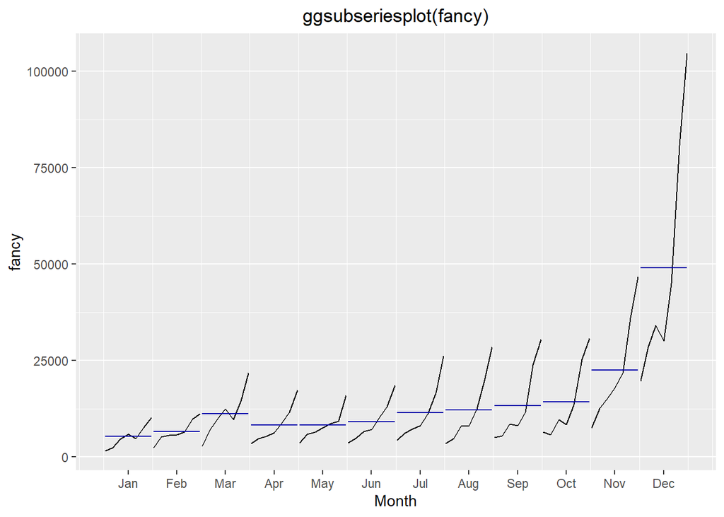

```r
ggsubseriesplot(fancy) +
  ggtitle("ggsubseriesplot(fancy)") +
  theme(text = element_text()) +
  theme(plot.title = element_text(hjust = 0.5))
```

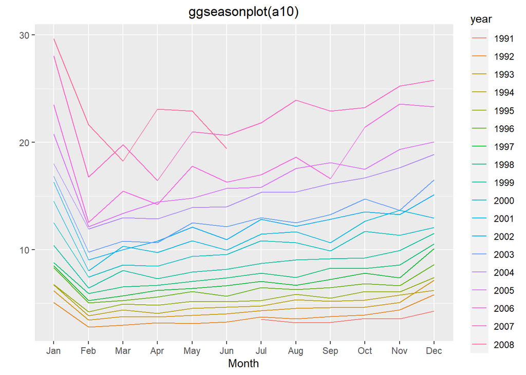

```r
ggseasonplot(a10) +
  ggtitle("ggseasonplot(a10)") +
  theme(text = element_text()) +
  theme(plot.title = element_text(hjust = 0.5))
```

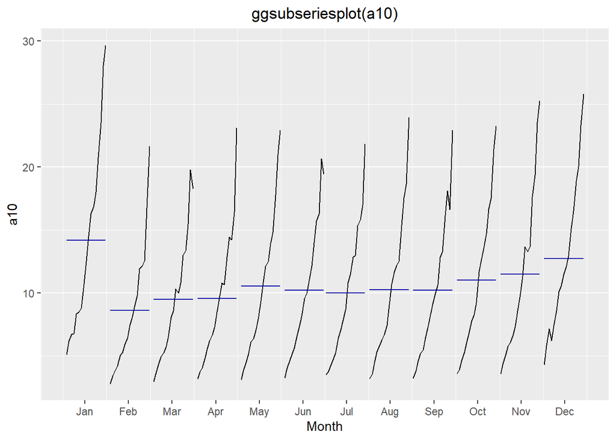

```r
ggsubseriesplot(a10) +
  ggtitle("ggsubseriesplot(a10)") +
  theme(text = element_text()) +
  theme(plot.title = element_text(hjust = 0.5))
```

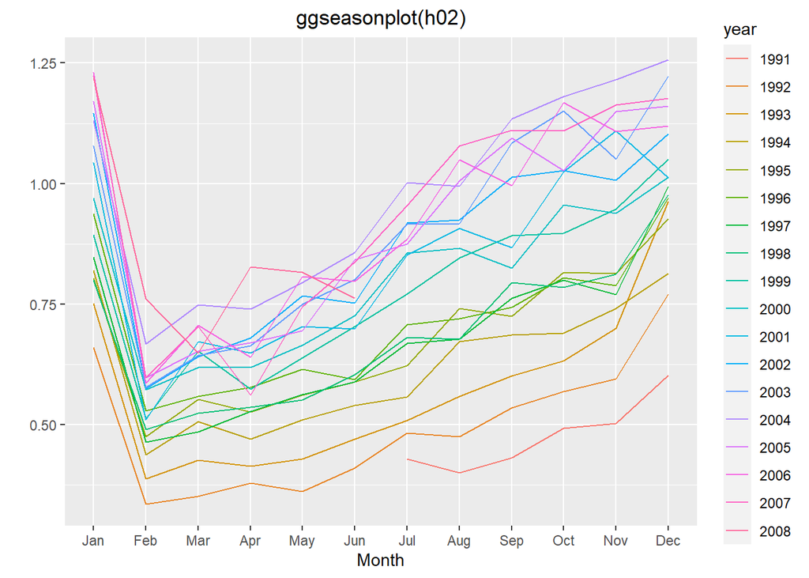

```r
ggseasonplot(h02) +
  ggtitle("ggseasonplot(h02)") +
  theme(text = element_text()) +
  theme(plot.title = element_text(hjust = 0.5))
```

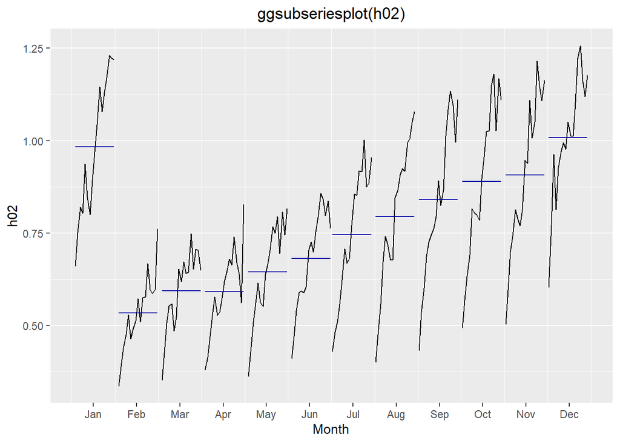

```r
ggsubseriesplot(h02) +
  ggtitle("ggsubseriesplot(h02)") +
  theme(text = element_text()) +
  theme(plot.title = element_text(hjust = 0.5))
```

6. 使用`autoplot()`、`ggseasonplot()`、`ggsubseriesplot()`、`gglagplot()`和`ggAcf()`这些画图函数，探索序列`hsales`、`usdeaths`、`bricksq`、`sunspotarea`和`gasoline`的特征。

- 你可以发现季节性、周期性或者趋势吗？
- 从这些序列中你发现了什么？

`hsales`

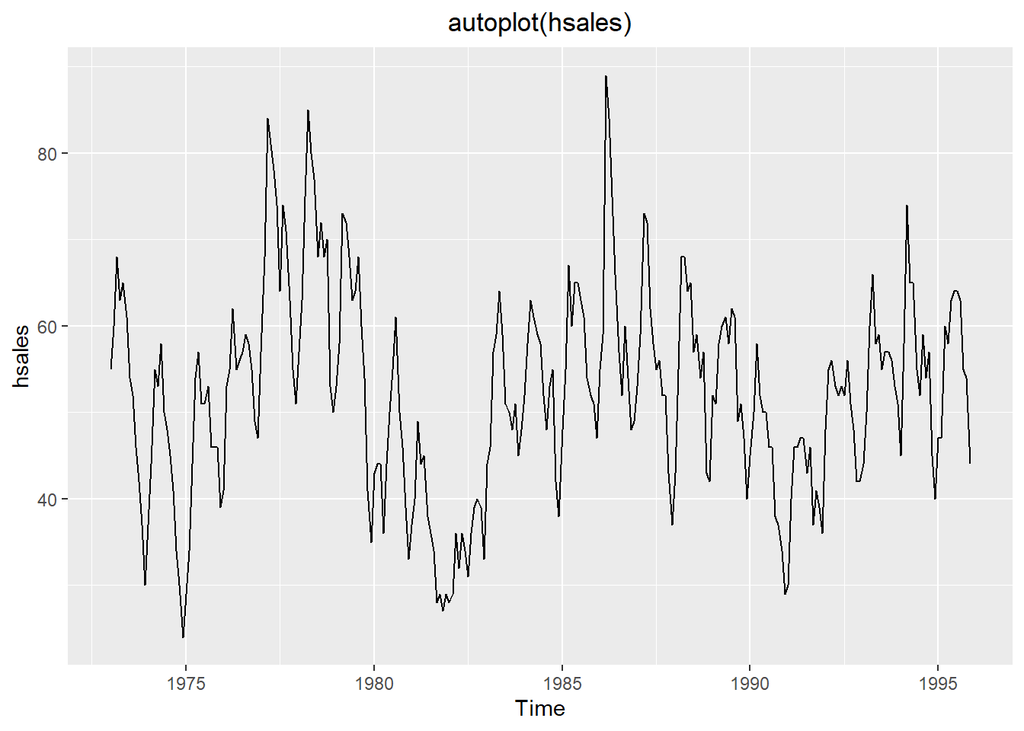

```r
autoplot(hsales) +
  ggtitle("autoplot(hsales)") +
  theme(text = element_text()) +
  theme(plot.title = element_text(hjust = 0.5))
```

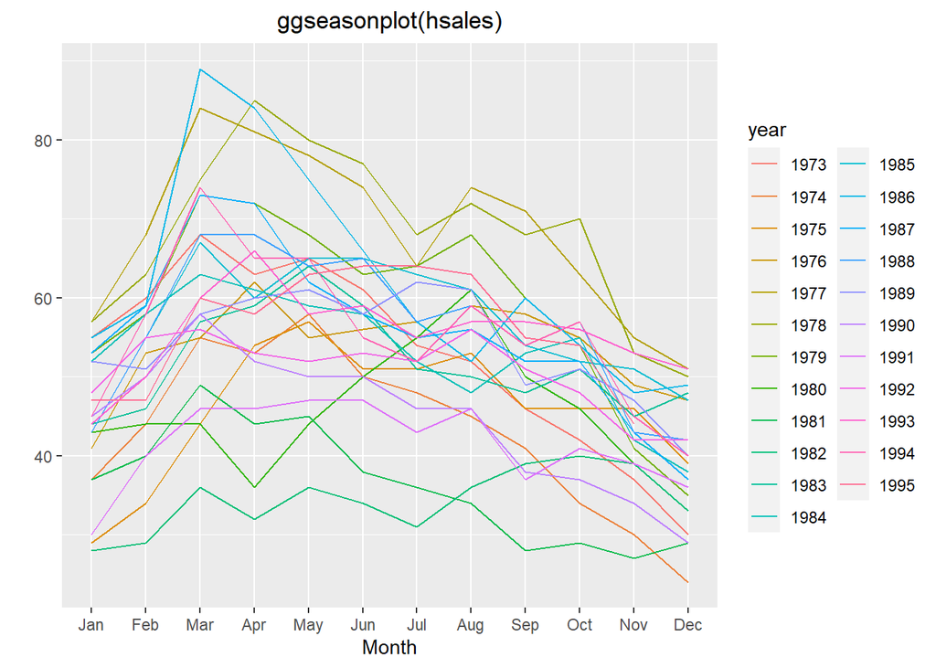

```r
ggseasonplot(hsales) +
  ggtitle("ggseasonplot(hsales)") +
  theme(text = element_text()) +
  theme(plot.title = element_text(hjust = 0.5))
```

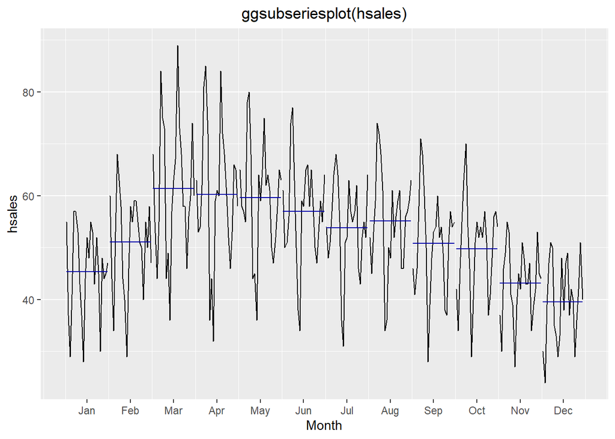

```r
ggsubseriesplot(hsales) +
  ggtitle("ggsubseriesplot(hsales)") +
  theme(text = element_text()) +
  theme(plot.title = element_text(hjust = 0.5))
```

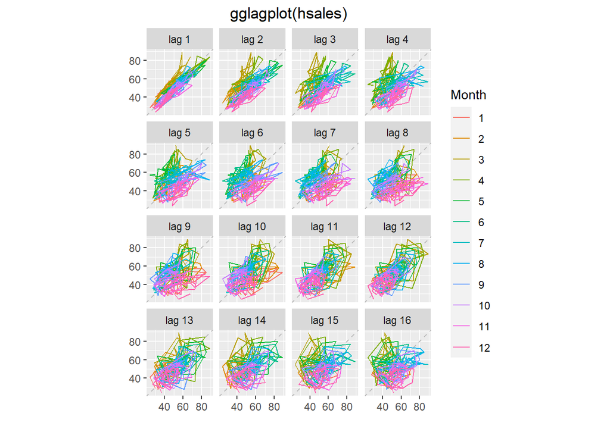

```r
gglagplot(hsales) +
  ggtitle("gglagplot(hsales)") +
  theme(text = element_text()) +
  theme(plot.title = element_text(hjust = 0.5))
```

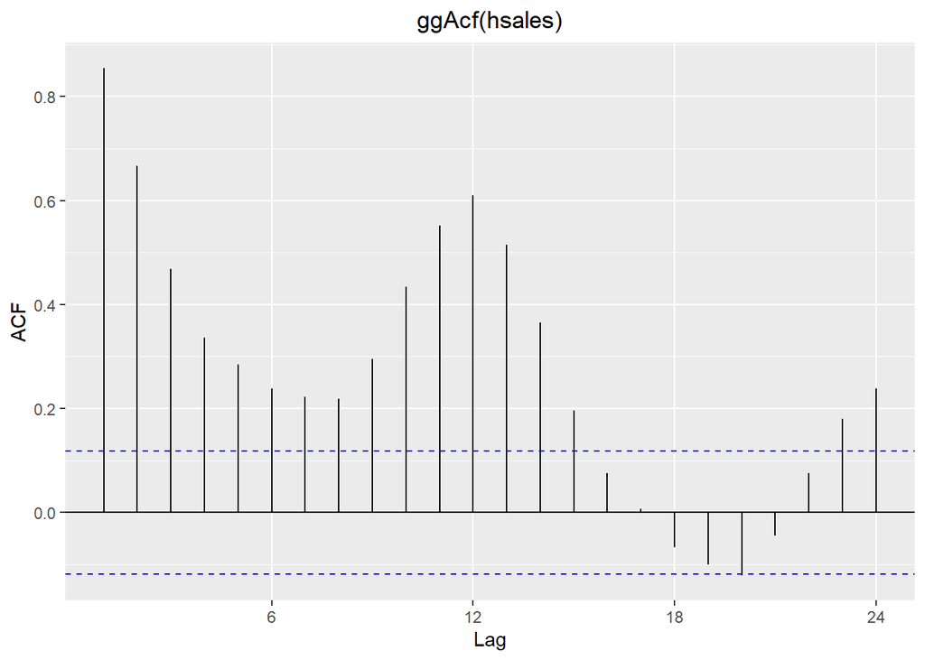

```r
ggAcf(hsales) +
  ggtitle("ggAcf(hsales)") +
  theme(text = element_text()) +
  theme(plot.title = element_text(hjust = 0.5))
```

`usdeaths`

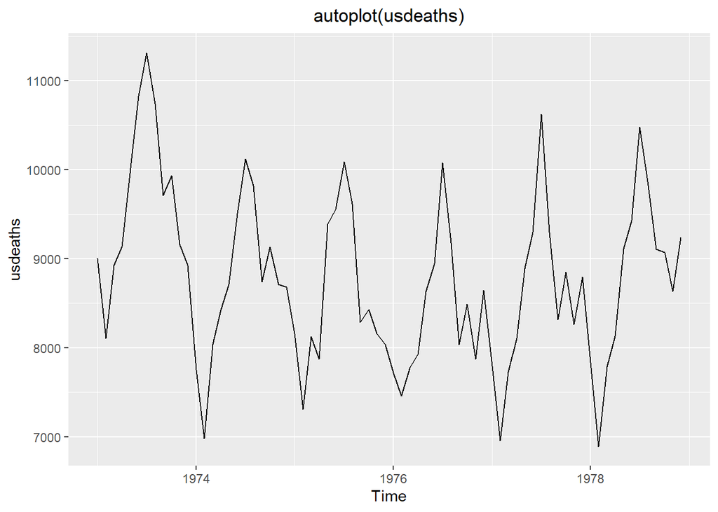

```r
autoplot(usdeaths) +
  ggtitle("autoplot(usdeaths)") +
  theme(text = element_text()) +
  theme(plot.title = element_text(hjust = 0.5))
```

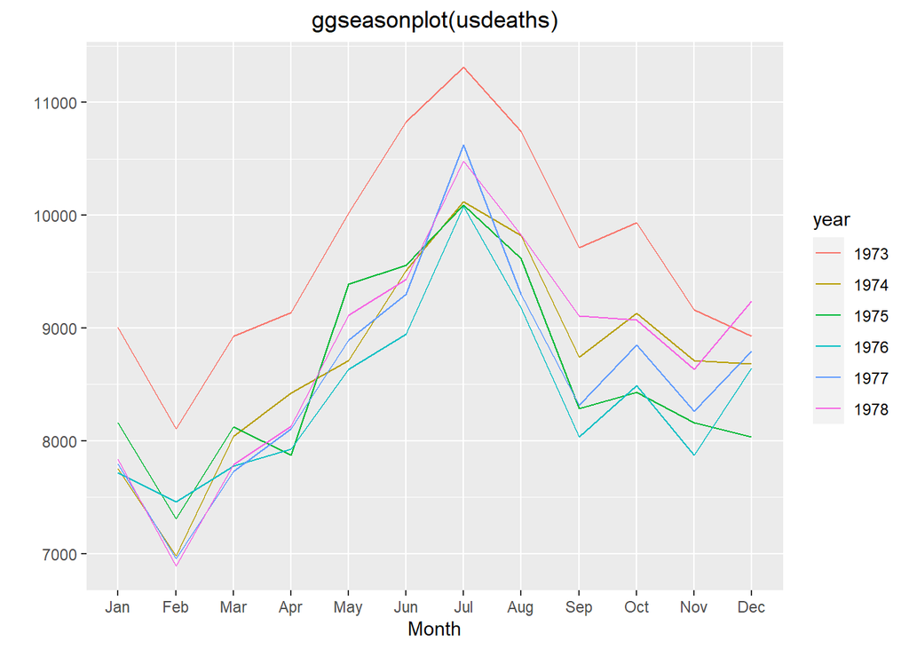

```r
ggseasonplot(usdeaths) +
  ggtitle("ggseasonplot(usdeaths)") +
  theme(text = element_text()) +
  theme(plot.title = element_text(hjust = 0.5))
```

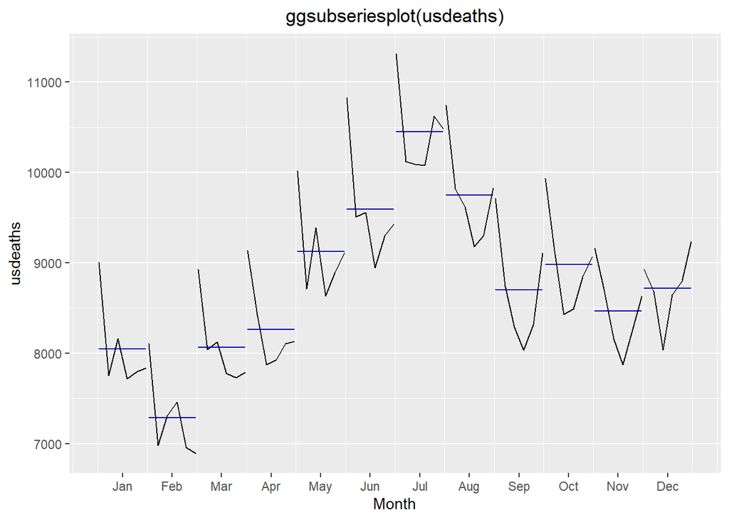

```r
ggsubseriesplot(usdeaths) +
  ggtitle("ggsubseriesplot(usdeaths)") +
  theme(text = element_text()) +
  theme(plot.title = element_text(hjust = 0.5))
```

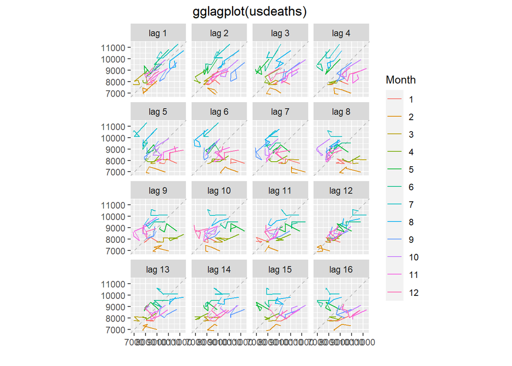

```r
gglagplot(usdeaths) +
  ggtitle("gglagplot(usdeaths)") +
  theme(text = element_text()) +
  theme(plot.title = element_text(hjust = 0.5))
```

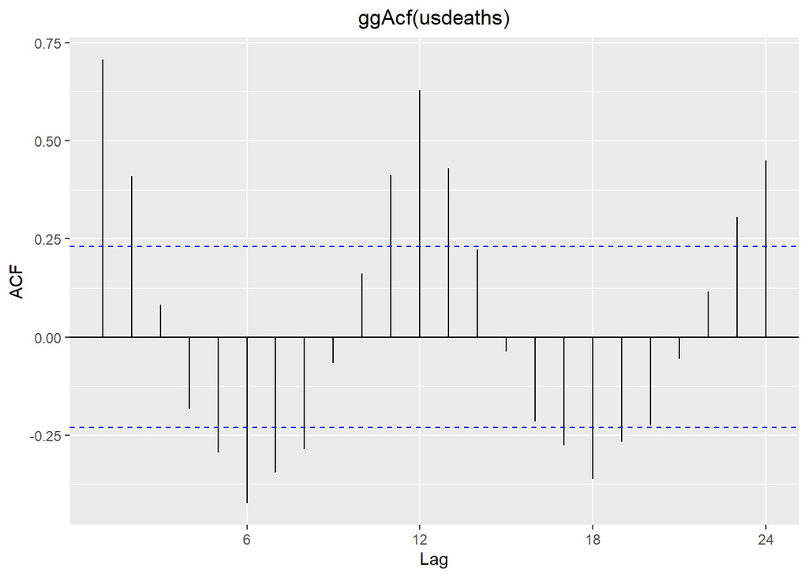

```r
ggAcf(usdeaths) +
  ggtitle("ggAcf(usdeaths)") +
  theme(text = element_text()) +
  theme(plot.title = element_text(hjust = 0.5))
```

`bricksq`

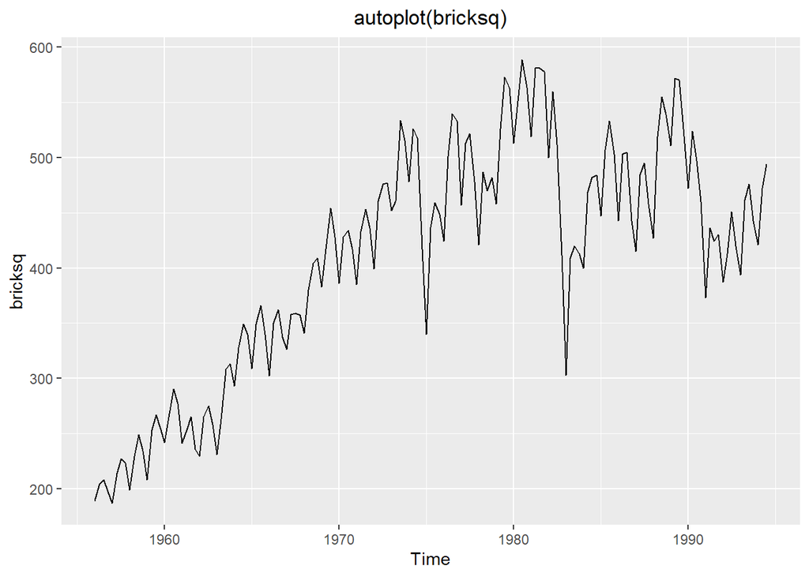

```r
autoplot(bricksq) +
  ggtitle("autoplot(bricksq)") +
  theme(text = element_text()) +
  theme(plot.title = element_text(hjust = 0.5))
```

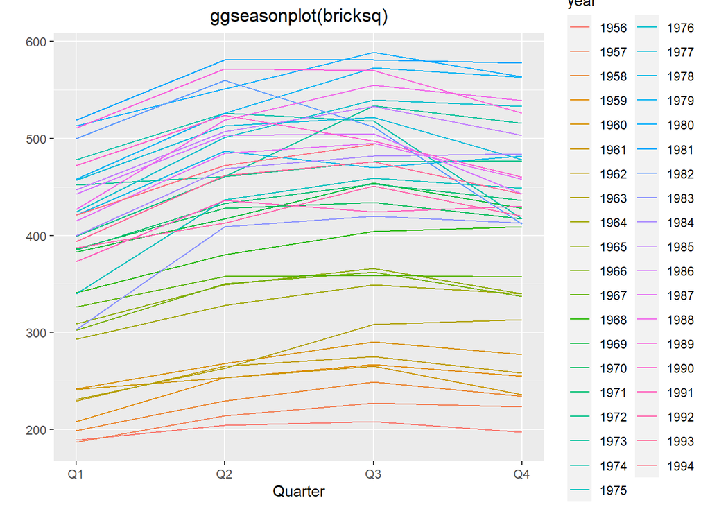

```r
ggseasonplot(bricksq) +
  ggtitle("ggseasonplot(bricksq)") +
  theme(text = element_text()) +
  theme(plot.title = element_text(hjust = 0.5))
```

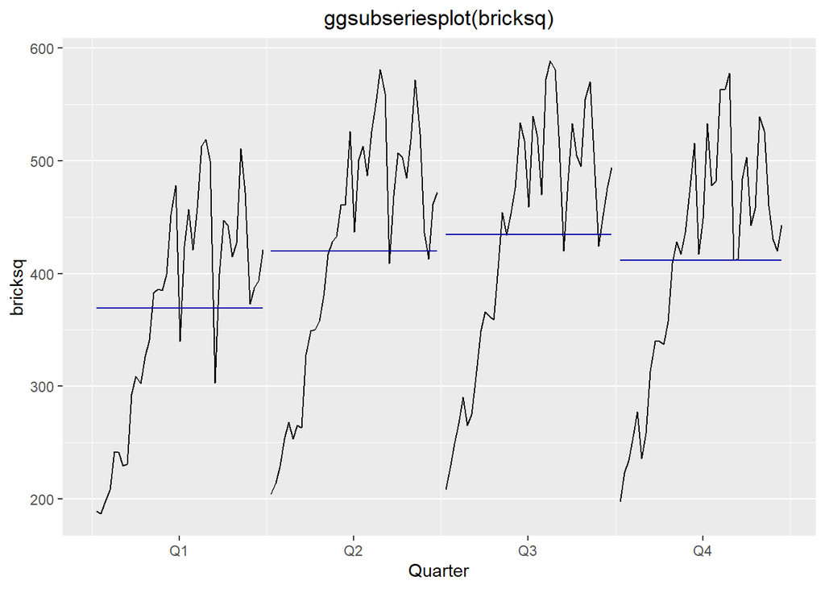

```r
ggsubseriesplot(bricksq) +
  ggtitle("ggsubseriesplot(bricksq)") +
  theme(text = element_text()) +
  theme(plot.title = element_text(hjust = 0.5))
```

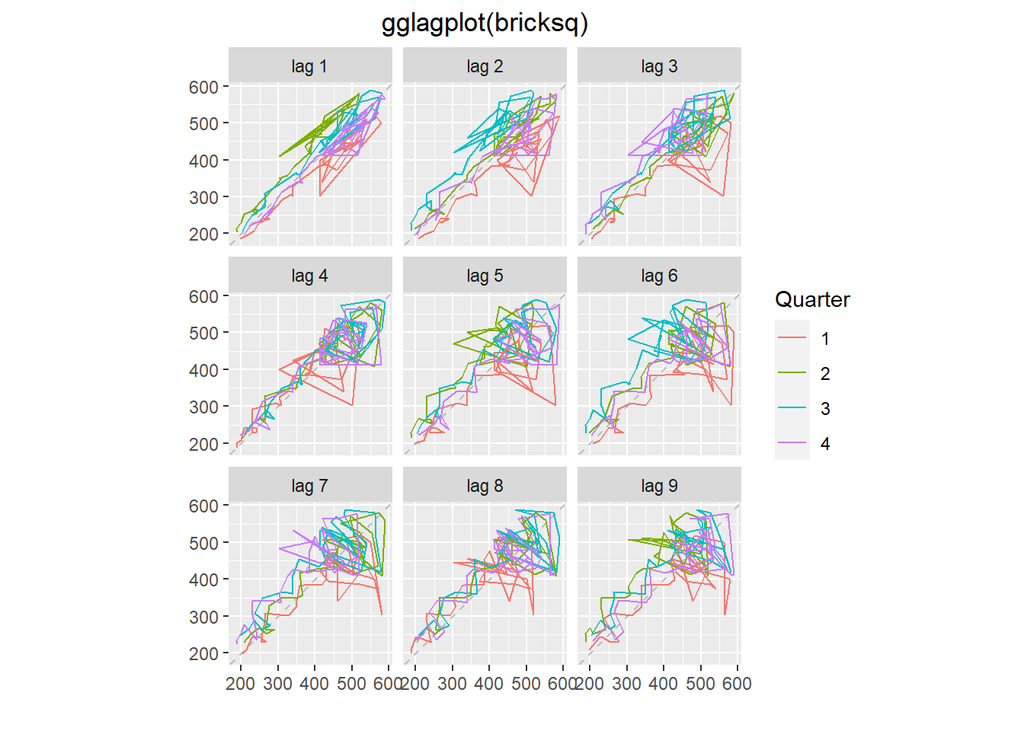

```r
gglagplot(bricksq) +
  ggtitle("gglagplot(bricksq)") +
  theme(text = element_text()) +
  theme(plot.title = element_text(hjust = 0.5))
```

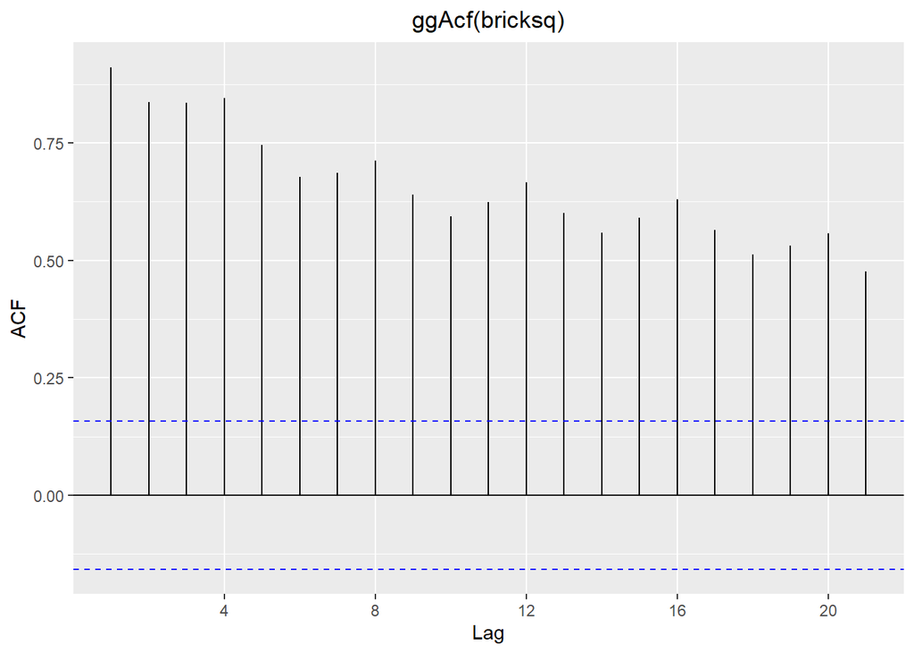

```r
ggAcf(bricksq) +
  ggtitle("ggAcf(bricksq)") +
  theme(text = element_text()) +
  theme(plot.title = element_text(hjust = 0.5))
```

`sunspotarea`

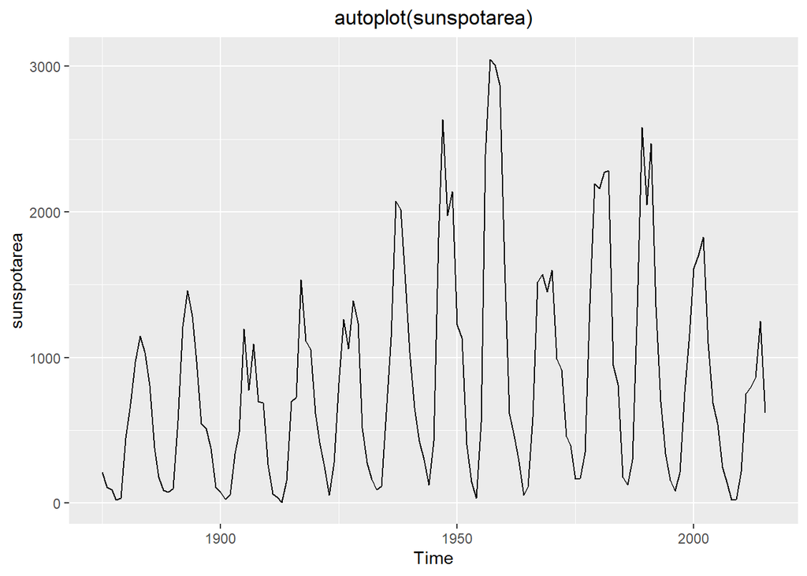

```r
autoplot(sunspotarea) +
  ggtitle("autoplot(sunspotarea)") +
  theme(text = element_text()) +
  theme(plot.title = element_text(hjust = 0.5))
```

```r
# ggseasonplot(sunspotarea) +
#   ggtitle("ggseasonplot(sunspotarea)") +
#   theme(text = element_text()) +
#   theme(plot.title = element_text(hjust = 0.5))

# ggseasonplot(sunspotarea) 中的错误 (Chapter-2-Time-series-graphics.rmd#606): Data are not seasonal
```

```r
# ggsubseriesplot(sunspotarea) +
#   ggtitle("ggsubseriesplot(sunspotarea)") +
#   theme(text = element_text()) +
#   theme(plot.title = element_text(hjust = 0.5))

# ggsubseriesplot(sunspotarea) 中的错误 (Chapter-2-Time-series-graphics.rmd#614): Data are not seasonal
```

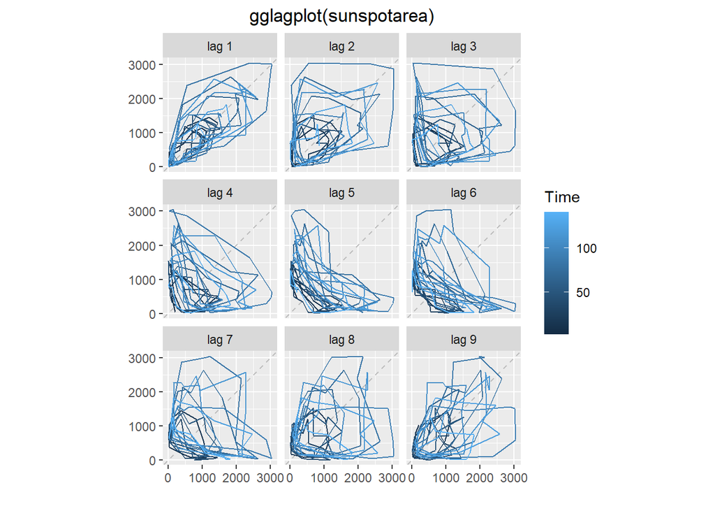

```r
gglagplot(sunspotarea) +
  ggtitle("gglagplot(sunspotarea)") +
  theme(text = element_text()) +
  theme(plot.title = element_text(hjust = 0.5))
```

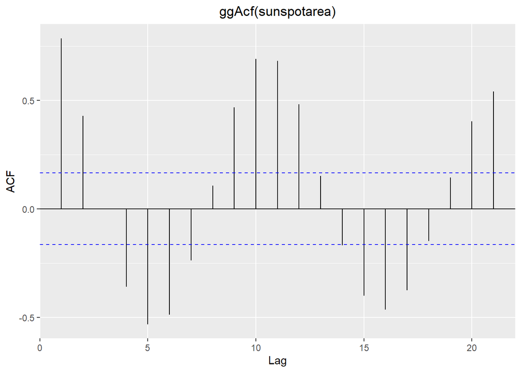

```r
ggAcf(sunspotarea) +
  ggtitle("ggAcf(sunspotarea)") +
  theme(text = element_text()) +
  theme(plot.title = element_text(hjust = 0.5))
```

`gasoline`

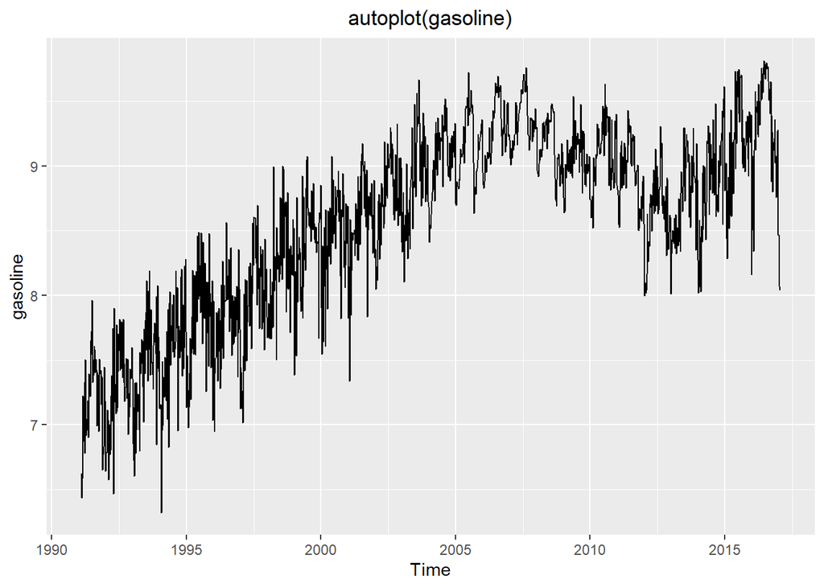

```r
autoplot(gasoline) +
  ggtitle("autoplot(gasoline)") +
  theme(text = element_text()) +
  theme(plot.title = element_text(hjust = 0.5))
```

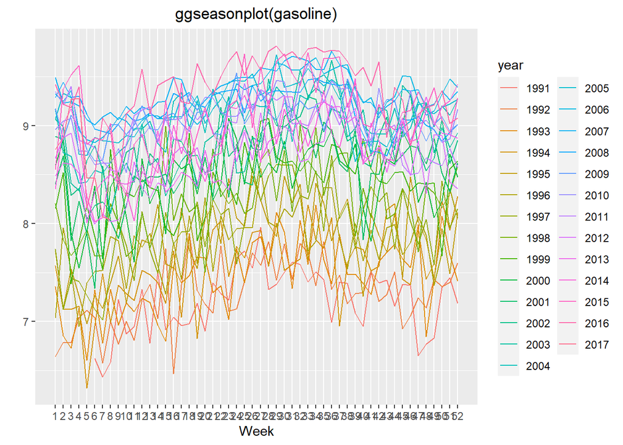

```r
ggseasonplot(gasoline) +
  ggtitle("ggseasonplot(gasoline)") +
  theme(text = element_text()) +
  theme(plot.title = element_text(hjust = 0.5))
```

```r
# ggsubseriesplot(gasoline) +
#   ggtitle("ggsubseriesplot(gasoline)") +
#   theme(text = element_text()) +
#   theme(plot.title = element_text(hjust = 0.5))

# ggsubseriesplot(gasoline) 中的错误 (Chapter-2-Time-series-graphics.rmd#648): Each season requires at least 2 observations. This may be caused from specifying a time-series with non-integer frequency.
```

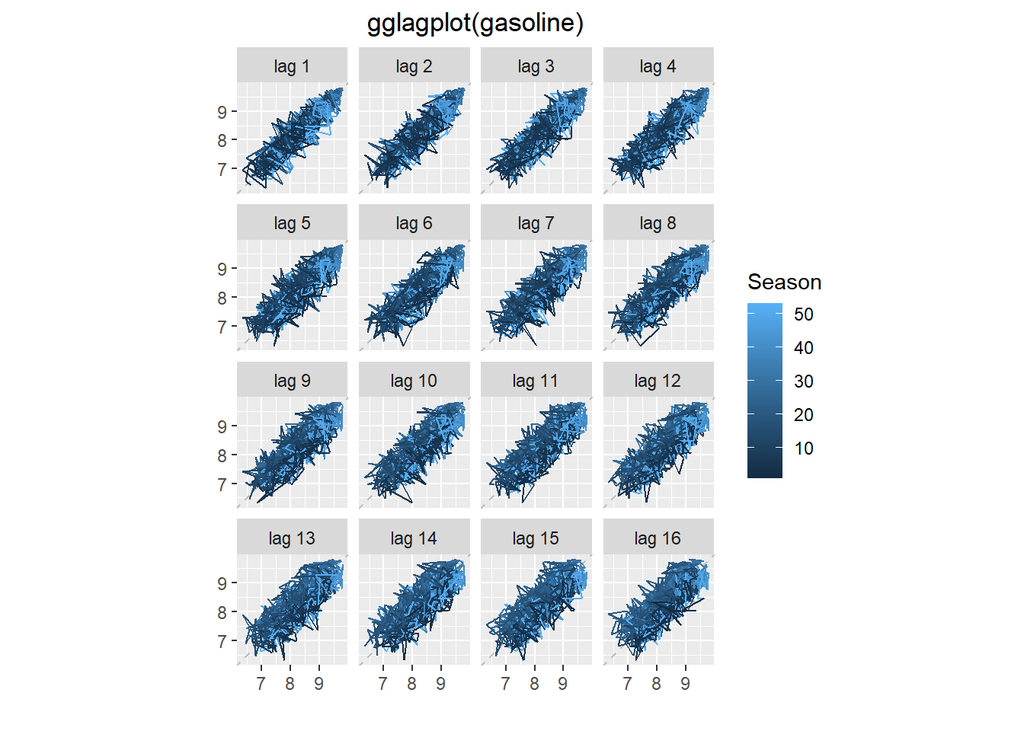

```r
gglagplot(gasoline) +
  ggtitle("gglagplot(gasoline)") +
  theme(text = element_text()) +
  theme(plot.title = element_text(hjust = 0.5))
```

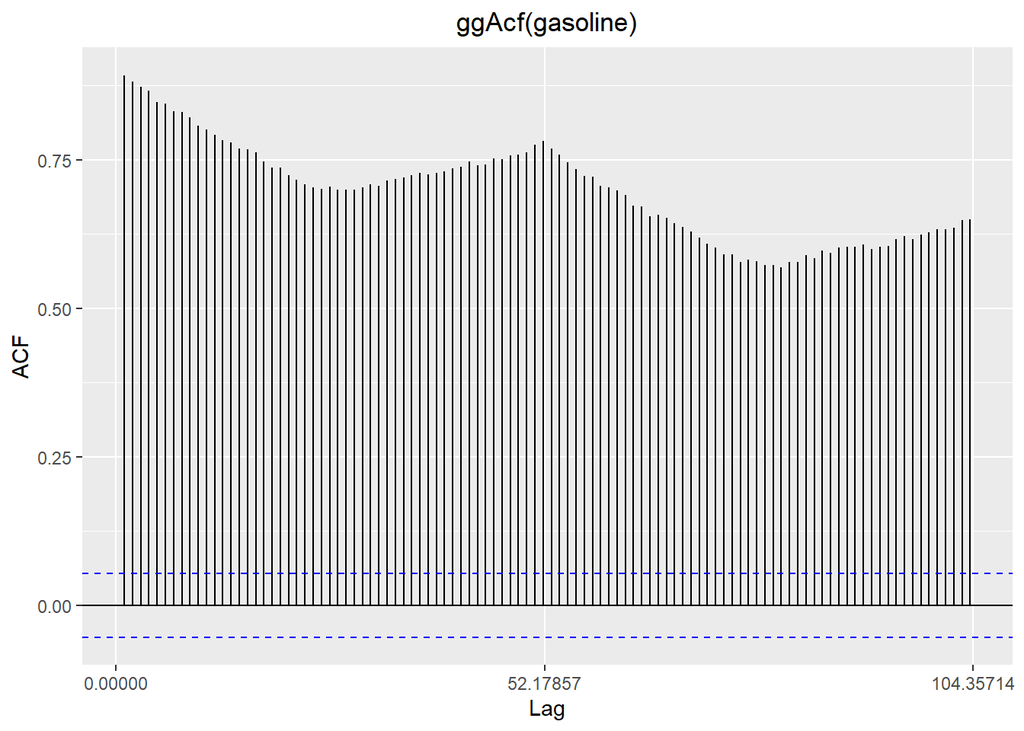

```r
ggAcf(gasoline) +
  ggtitle("ggAcf(gasoline)") +
  theme(text = element_text()) +
  theme(plot.title = element_text(hjust = 0.5))
```

7. `arrivals`数据包括从日本、新西兰、英国和美国到达澳大利亚的人数（千）。

- 使用`autoplot()`、`ggseasonplot()`和`ggsubseriesplot()`函数比较四个国家到达澳大利亚人数的不同之处。
- 你可以找出异常观测点吗？

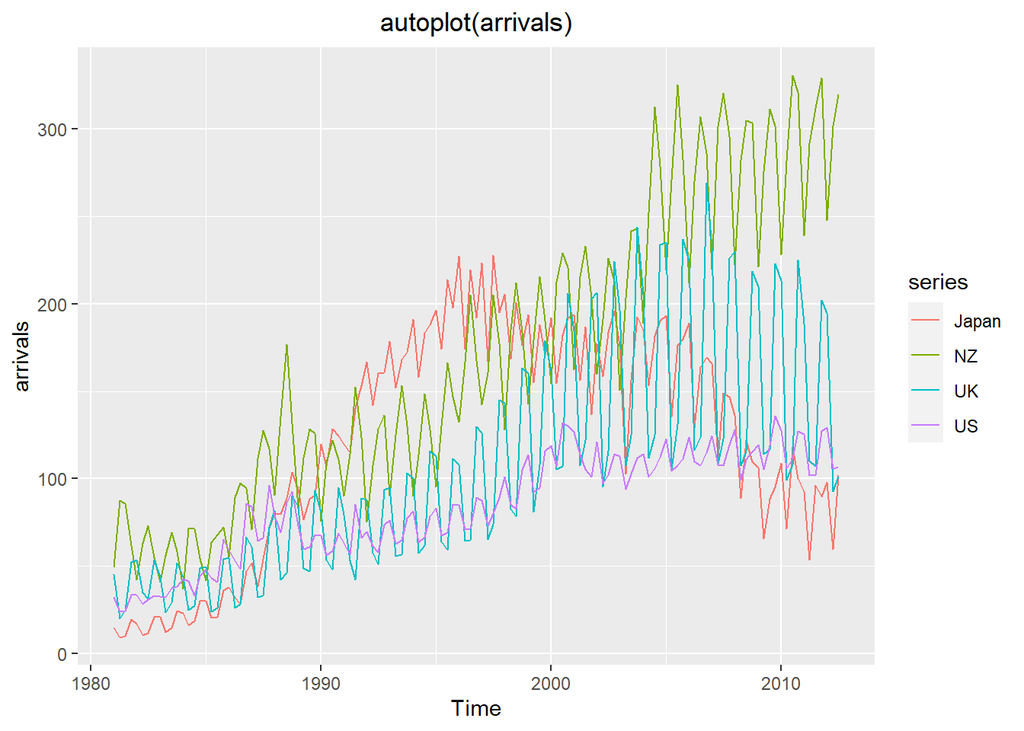

```r
autoplot(arrivals) +
  ggtitle("autoplot(arrivals)") +
  theme(text = element_text()) +
  theme(plot.title = element_text(hjust = 0.5))
```

```r
# ggseasonplot(arrivals) +
#   ggtitle("ggseasonplot(arrivals)") +
#   theme(text = element_text()) +
#   theme(plot.title = element_text(hjust = 0.5))

# data.frame(y = as.numeric(x), year = trunc(round(time(x), 8)),  中的错误 (Chapter 2 Time series graphics.rmd#679): 参数值意味着不同的行数: 508, 127
```

```r
# ggsubseriesplot(arrivals) +
#   ggtitle("ggsubseriesplot(arrivals)") +
#   theme(text = element_text()) +
#   theme(plot.title = element_text(hjust = 0.5))

# data.frame(y = as.numeric(x), year = trunc(time(x)), season = as.numeric(phase)) 中的错误 (Chapter 2 Time series graphics.rmd#687): 参数值意味着不同的行数: 508, 127
```

8. 下列时间序列图和ACF图分别对应四个不同的时间序列。你的任务是将第一行的时间序列图和第二行的ACF图分别对应。

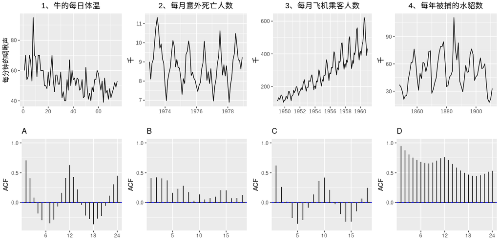

9. 数据集`pigs`是从1980年1月到1995年8月，维多利亚州每月屠宰猪的总量。使用`mypigs <- window(pigs, start=1990)`截取1990年之后的数据。运用`autoplot`和`ggAcf`函数分别画出`mypigs`及其ACF图，并将其结果与白噪声的结果（如图[2.17](https://otexts.com/fppcn/wn.html#fig:wnoise)和[2.18](https://otexts.com/fppcn/wn.html#fig:wnoiseacf)所示）进行比较。

```r
mypigs <- window(pigs, start=1990)
```

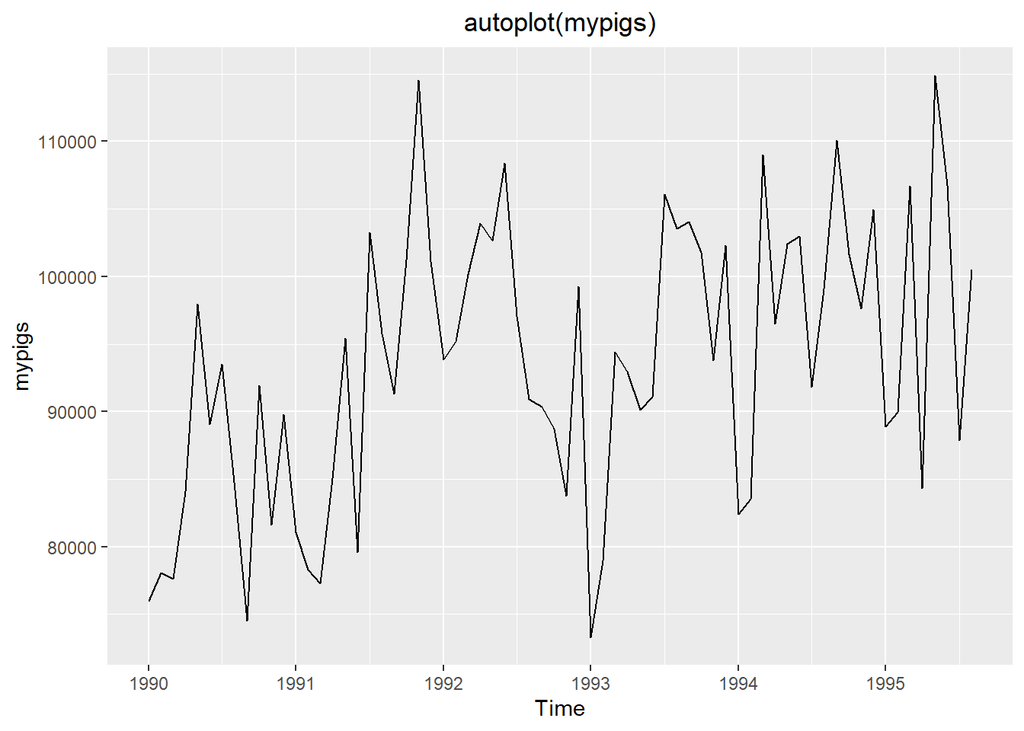

```r
autoplot(mypigs) +
  ggtitle("autoplot(mypigs)") +
  theme(text = element_text()) +
  theme(plot.title = element_text(hjust = 0.5))
```

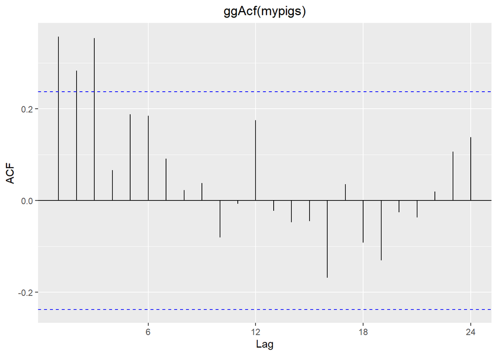

```r
ggAcf(mypigs) +
  ggtitle("ggAcf(mypigs)") +
  theme(text = element_text()) +
  theme(plot.title = element_text(hjust = 0.5))
```

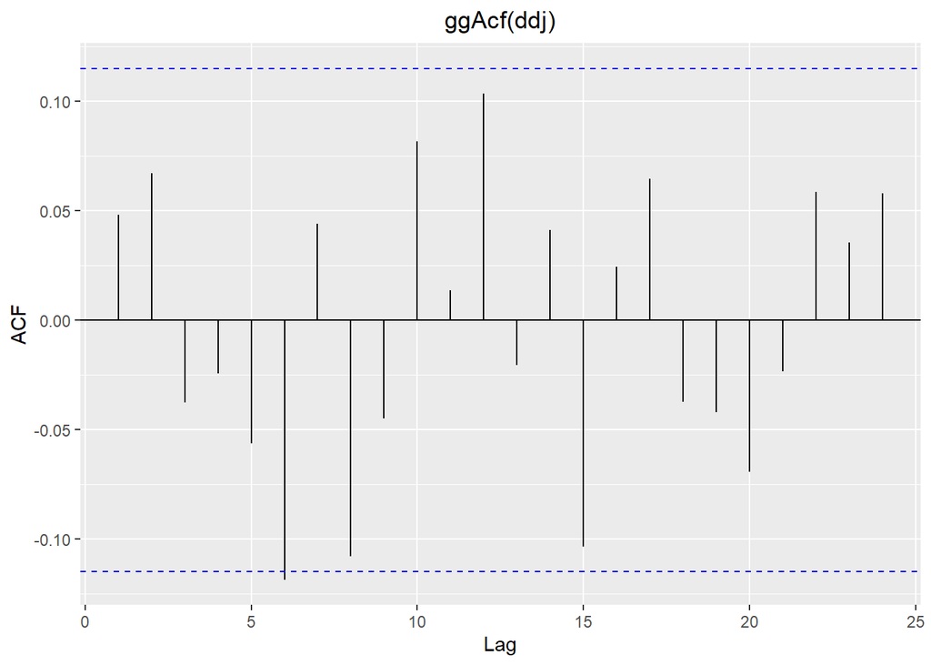

```r
ddj <- diff(dj)
ggAcf(ddj) +
  ggtitle("ggAcf(ddj)") +
  theme(text = element_text()) +
  theme(plot.title = element_text(hjust = 0.5))
```